# Group_14_Analysis

Author

Tianrui Xie

Published

March 18, 2025

# Data Analysis Report

## **1.** Data Loading

In this project, we used `dataset14.csv`, which contains coffee quality ratings as well as some chemical characteristics such as `aroma`, `flavor`, and `acidity`.

First, we load the data and examine its structure, including:

- The types of variables (numerical, categorical)
- Missing values
- Basic statistical information of variables (mean, median, standard deviation, etc.)

This helps us understand the fundamental characteristics of the data, preparing for subsequent data cleaning and analysis.

```
'data.frame':   1134 obs. of  8 variables:
 $ country_of_origin   : chr  "China" "Mexico" "Brazil" "United States (Hawaii)" ...
 $ aroma               : num  7.25 7.58 8.25 7.92 7.42 7.67 7.42 7.42 7.67 7.25 ...
 $ flavor              : num  7.08 7.08 7.83 7.92 7.33 7.83 7.5 7.58 7.67 7.08 ...
 $ acidity             : num  7.17 7.58 8.33 7.92 7.58 7.92 7.42 7.17 7.67 7.33 ...
 $ category_two_defects: int  14 4 0 6 0 7 10 0 4 45 ...
 $ altitude_mean_meters: num  1700 1022 1268 NA NA ...
 $ harvested           : int  2013 2013 2016 2012 2013 2015 2015 NA 2014 2012 ...
 $ Qualityclass        : chr  "Poor" "Poor" "Poor" "Good" ...
```

```
 country_of_origin      aroma           flavor         acidity
 Length:1134        Min.   :0.000   Min.   :0.000   Min.   :0.000
 Class :character   1st Qu.:7.420   1st Qu.:7.330   1st Qu.:7.330
 Mode  :character   Median :7.580   Median :7.580   Median :7.580
                    Mean   :7.568   Mean   :7.523   Mean   :7.538
                    3rd Qu.:7.750   3rd Qu.:7.750   3rd Qu.:7.750
                    Max.   :8.750   Max.   :8.830   Max.   :8.750

 category_two_defects altitude_mean_meters   harvested    Qualityclass
 Min.   : 0.000       Min.   :     1       Min.   :2010   Length:1134
 1st Qu.: 0.000       1st Qu.:  1100       1st Qu.:2012   Class :character
 Median : 2.000       Median :  1311       Median :2014   Mode  :character
 Mean   : 3.501       Mean   :  1653       Mean   :2014
 3rd Qu.: 4.000       3rd Qu.:  1600       3rd Qu.:2015
 Max.   :55.000       Max.   :190164       Max.   :2018
                      NA's   :199          NA's   :59
```

## **2.** Data Cleaning

During the data cleaning process, we performed the following operations:

### Handling Missing Values:

- **`country_of_origin` (Coffee Origin):** Few missing values, so we directly removed the corresponding rows.
- **`altitude_mean_meters` (Altitude):** Filled missing values with the median, as altitude data might have a skewed distribution.
- **`harvested` (Harvest Year):** Filled missing values with the mode, as the year is a discrete variable, making the mode the most reasonable imputation method.

### Handling Outliers:

- **`altitude_mean_meters`:** The maximum value was found to be 190,164m, which is clearly abnormal. Therefore, we removed observations above 5,000m.

### Variable Transformation:

- **`category_two_defects` (Number of Secondary Defects):** Highly right-skewed, so we applied a log transformation (`log+1`) to reduce the influence of extreme values.
- **`Qualityclass` (Quality Grade):** A categorical variable that was binarized (`Good = 1`, `Poor = 0`) to facilitate logistic regression analysis.

After data cleaning, the dataset has no missing values, major outliers have been removed, and the data quality is ensured to be reliable.

```
 country_of_origin      aroma           flavor         acidity
 Length:1129        Min.   :5.080   Min.   :6.080   Min.   :5.250
 Class :character   1st Qu.:7.420   1st Qu.:7.330   1st Qu.:7.330
 Mode  :character   Median :7.580   Median :7.580   Median :7.580
                    Mean   :7.576   Mean   :7.531   Mean   :7.545
                    3rd Qu.:7.750   3rd Qu.:7.750   3rd Qu.:7.750
                    Max.   :8.750   Max.   :8.830   Max.   :8.750
 category_two_defects altitude_mean_meters   harvested    Qualityclass
 Min.   : 0.000       Min.   :   1         Min.   :2010   Length:1129
 1st Qu.: 0.000       1st Qu.:1200         1st Qu.:2012   Class :character
 Median : 2.000       Median :1311         Median :2013   Mode  :character
 Mean   : 3.492       Mean   :1322         Mean   :2014
 3rd Qu.: 4.000       3rd Qu.:1550         3rd Qu.:2015
 Max.   :55.000       Max.   :4287         Max.   :2018
 category_two_defects_log Qualityclass_binary
 Min.   :0.000            Min.   :0.0000
 1st Qu.:0.000            1st Qu.:0.0000
 Median :1.099            Median :1.0000
 Mean   :1.084            Mean   :0.5146
 3rd Qu.:1.609            3rd Qu.:1.0000
 Max.   :4.025            Max.   :1.0000
```

## **3.** Exploratory Data Analysis (EDA)

### **3.1** Data Distribution

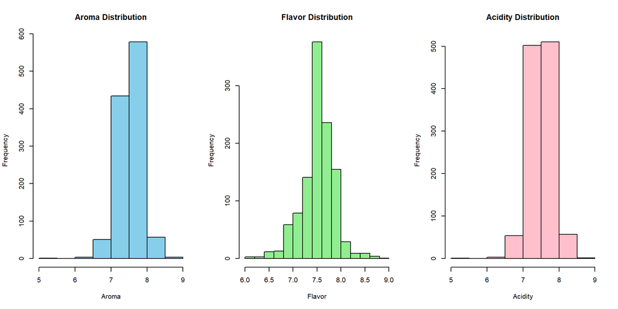

In the exploratory data analysis (EDA), we first examined the distribution of several key variables:

- **`Aroma`:** Mainly concentrated between 7.0 and 8.5, following a normal distribution.
- **`Flavor`:** Similar to aroma, with most values above 7.0.
- **`Acidity`:** Its distribution is close to that of aroma but slightly skewed.

Overall, aroma, flavor, and acidity share similar distribution patterns, suggesting a potential strong correlation among them. This will be further confirmed in the subsequent correlation analysis.

### **3.2** Variable Correlation

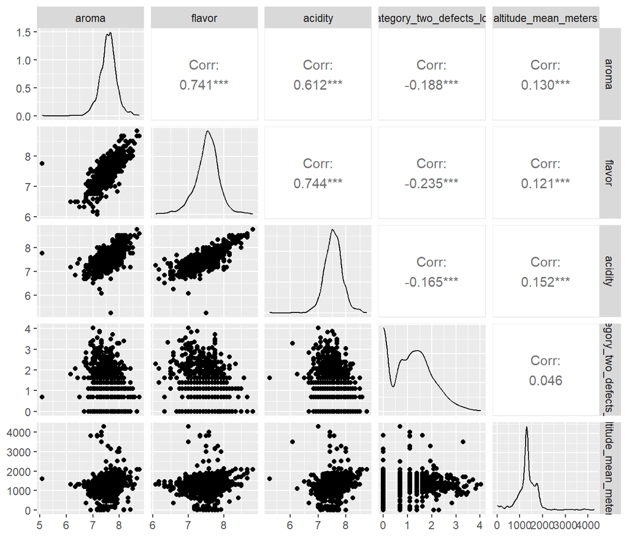

- **`Aroma`**, **`flavor`**, and **`acidity`** exhibit a strong correlation (0.6–0.8), indicating that they may have a similar impact on **`Qualityclass`**.
- **`Category_two_defects_log`** might be related to **`Qualityclass`**, but it shows a lower correlation with **`aroma and flavor`**.
- **`Altitude_mean_meters`** appears to have a minimal effect on **`Qualityclass`**.

This analysis provides a foundation for our GLM modeling, where we will further examine the influence of these variables in the regression model.

## **4. Generalized Linear Model (**GLM)

To predict the coffee quality grade (**`Qualityclass`**), we used a Generalized Linear Model (GLM), where:

- **Response Variable**：`Qualityclass_binary`（`Good=1`，`Poor=0`）
- **Predictor Variables**：
  - `aroma`
  - `flavor`
  - `acidity`
  - `altitude_mean_meters`
  - `harvested`
  - `category_two_defects_log`

```
Call:
glm(formula = Qualityclass_binary ~ aroma + flavor + acidity +
    altitude_mean_meters + harvested + category_two_defects_log,
    family = binomial, data = df)

Coefficients:
                           Estimate Std. Error z value Pr(>|z|)
(Intercept)              -2.098e+02  1.066e+02  -1.969   0.0490 *
aroma                     4.323e+00  5.922e-01   7.300 2.88e-13 ***
flavor                    7.424e+00  7.409e-01  10.020  < 2e-16 ***
acidity                   3.246e+00  5.429e-01   5.978 2.26e-09 ***
altitude_mean_meters      4.299e-04  2.092e-04   2.055   0.0399 *
harvested                 4.767e-02  5.267e-02   0.905   0.3654
category_two_defects_log  6.155e-02  1.186e-01   0.519   0.6037
---
Signif. codes:  0 '***' 0.001 '**' 0.01 '*' 0.05 '.' 0.1 ' ' 1

(Dispersion parameter for binomial family taken to be 1)

    Null deviance: 1564.16  on 1128  degrees of freedom
Residual deviance:  675.48  on 1122  degrees of freedom
AIC: 689.48

Number of Fisher Scoring iterations: 7
```

The model equation is as follows:：

$$\begin{aligned}
\log\left(\frac{P(\mathrm{Good})}{1-P(\mathrm{Good})}\right)=-209.8+4.32\cdot\mathrm{aroma}+7.42\cdot\mathrm{flavor}+3.25\cdot\mathrm{acidity}+0.0004299\cdot\\\mathrm{altitude\_mean\_meters}+0.0477\cdot\mathrm{harvested}+0.0616\cdot\mathrm{category\_two\_defects\_log}
\end{aligned}$$

## Variable Interpretation

### **1.** Key Influencing Factors

- **`flavor`**
  - **Coefficient = 7.42**, **p < 0.001** (highly significant).
  - This indicates that for every 1-point increase in flavor score, the log-odds of the coffee being rated as “Good” increases by 7.42.
  - Flavor remains the most critical influencing factor.
- **`aroma`**
  - **Coefficient = 4.32, p < 0.001** (highly significant).
  - A 1-point increase in aroma score significantly increases the probability of the coffee being rated as “Good”.
- **`acidity`**
  - **Coefficient = 3.25, p < 0.001** (highly significant).
  - An increase in acidity enhances the coffee quality grade.

### **2.** Factors with Minor or Insignificant Influence

- **`altitude_mean_meters`**
  - **Coefficient = 0.0004299, p = 0.0399** (significant).
  - Although the coefficient is small, it still suggests that higher altitude may have a **positive impact** on coffee quality.
- **`harvested`**
  - **Coefficient = 0.0477, p = 0.3654** (not significant).

### **Model Refinement:**

We ultimately discard `altitude_mean_meters`, `harvested`, and `category_two_defects_log` and **refit the model**, obtaining a **new refined model**.

```
Call:
glm(formula = Qualityclass_binary ~ aroma + flavor + acidity,
    family = binomial, data = df)

Coefficients:
             Estimate Std. Error z value Pr(>|z|)
(Intercept) -113.0519     7.1776 -15.751  < 2e-16 ***
aroma          4.3619     0.5929   7.357 1.88e-13 ***
flavor         7.2856     0.7313   9.963  < 2e-16 ***
acidity        3.3281     0.5402   6.161 7.24e-10 ***
---
Signif. codes:  0 '***' 0.001 '**' 0.01 '*' 0.05 '.' 0.1 ' ' 1

(Dispersion parameter for binomial family taken to be 1)

    Null deviance: 1564.16  on 1128  degrees of freedom
Residual deviance:  680.53  on 1125  degrees of freedom
AIC: 688.53

Number of Fisher Scoring iterations: 7
```

At this point, the **model equation** is:

$$\begin{aligned}
\log\left(\frac{P(\mathrm{Good})}{1-P(\mathrm{Good})}\right)=-113.1+4.36\cdot\mathrm{aroma}+7.28\cdot\mathrm{flavor}+3.32\cdot\mathrm{acidity}
\end{aligned}$$

## **5.** Model Evaluation

Calculate **AUC-ROC** and **Confusion Matrix**

```
[1] "Accuracy: 0.87422497785651"
```

```
[1] "AUC-ROC: 0.944124778572057"
```

```
[1] "Confusion Matrix:"
```

```
         Actual
Predicted   0   1
        0 472  66
        1  76 515
```

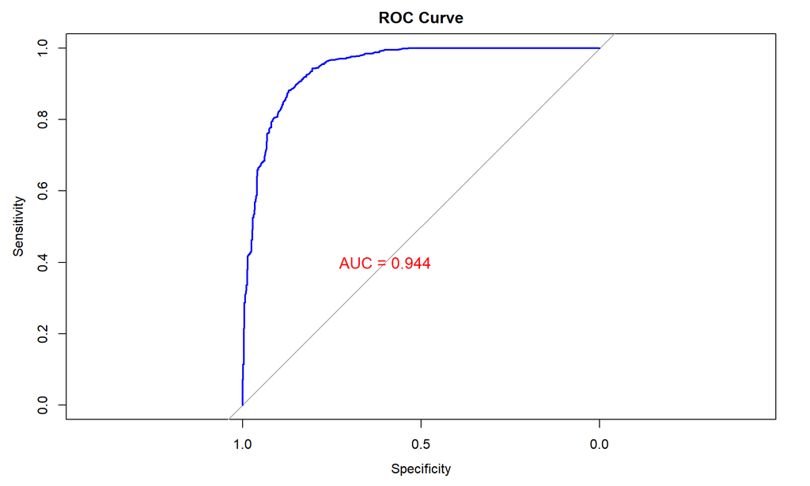

### 1.AOC snd ROC

- **AUC-ROC = 0.944**
- The ROC curve is very close to the top-left corner, indicating that the model has **strong discriminative power**.
- An **AUC > 0.9** is generally considered an **excellent classifier**, meaning the model can effectively distinguish between different categories of data.

#### **Conclusion**

  Your model performs **exceptionally well** in distinguishing between **high-quality** and **low-quality** coffee categories, with a **low error rate**.

### **2.Confusion Matrix Analysis**

#### Actual vs. Predicted Classes

**Accuracy = 87.42%**

This means that 87.42% of all samples were correctly classified.

#### **Conclusion & Optimization Suggestions**

- The model performs **well overall**, but **misclassification still exists**.
- **Threshold tuning** may help optimize the balance between FN and FP, depending on whether minimizing false positives or false negatives is more important for the application.

### **3.Residual Analysis**

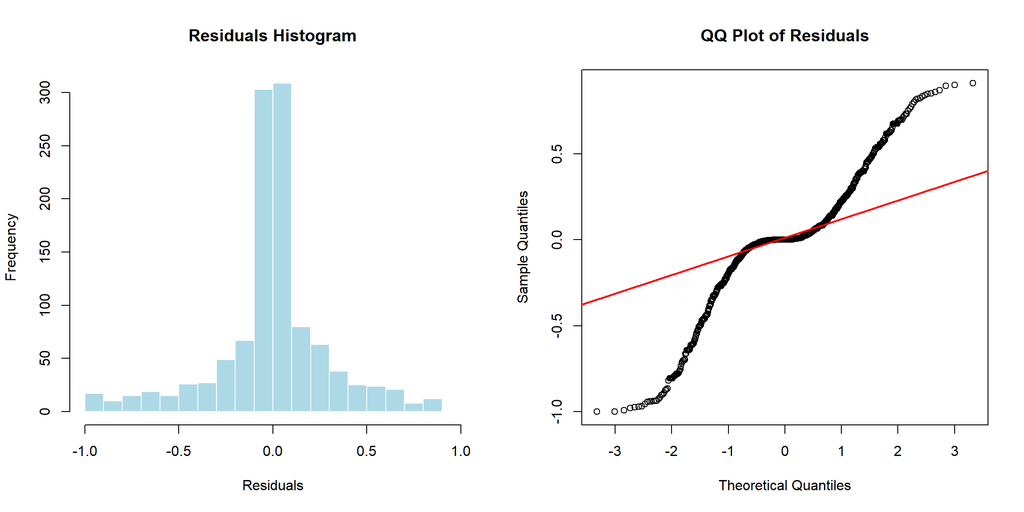

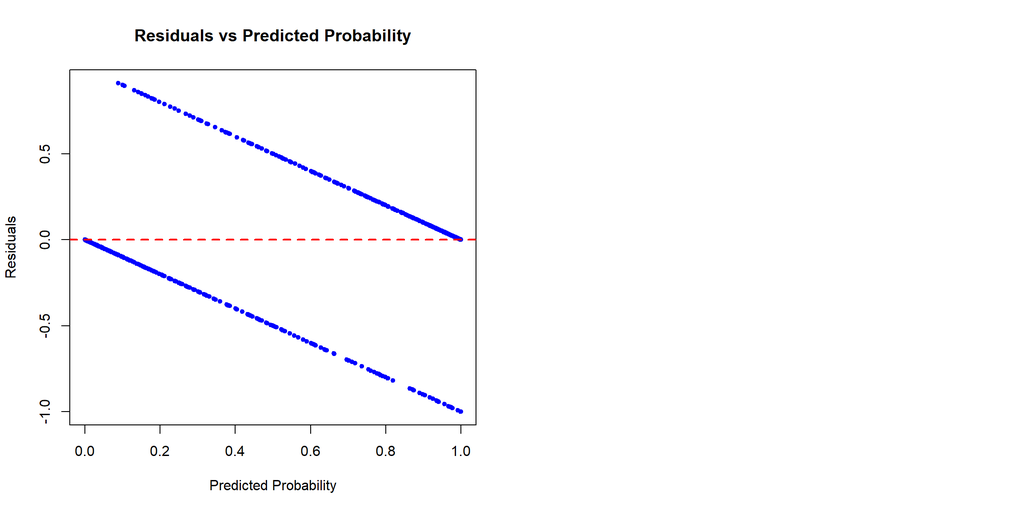

#### **（3）Residuals vs. Predicted Values**

- **Purpose:**  
  This plot is used to check for heteroscedasticity, i.e., whether the error variance changes with predicted values.
- **Observations:**
  - The residuals are not completely randomly distributed but show two distinct clustering patterns, likely related to the binary classification nature of the problem.
  - This may indicate limitations in the linearity assumption of the model.
- **Possible Solutions:**
  - Consider using nonlinear models (e.g., decision trees or random forests).
  - Introduce interaction terms or higher-order terms to improve the model fit.
- **Conclusion:**

```
The current model's residuals show some structured patterns, suggesting that further optimization of the model structure or variable selection may be necessary.
```